# Introdução à impressão 3D

Oficina prática de introdução à impressão 3D · 180 minutos

IFSC · Oficina presencial

## Objetivos da oficina

Nesta oficina, vamos acompanhar uma Ender 3 Pro fabricando um brinde e analisar um modelo Benchy no PrusaSlicer.

### Ao final da oficina, você deverá conseguir

- explicar a diferença entre fabricação aditiva, subtrativa e formativa;
- reconhecer os principais componentes de uma impressora FDM;
- baixar, extrair e executar um aplicativo portátil no Windows;
- importar um STL, fatiá-lo e interpretar o preview por camadas;
- relacionar uma decisão de configuração com tempo, material e qualidade.

**A impressão começa agora.** Observe tempo, camadas, movimentos e acabamento. O resultado será sorteado ao final.

## Processos de fabricação: exemplos reais

**FDM/FFF · filamento**  
O bico deposita termoplástico aquecido.

[figure not shown]

**SLA/MSLA · resina**  
Uma fonte de luz cura regiões da resina.

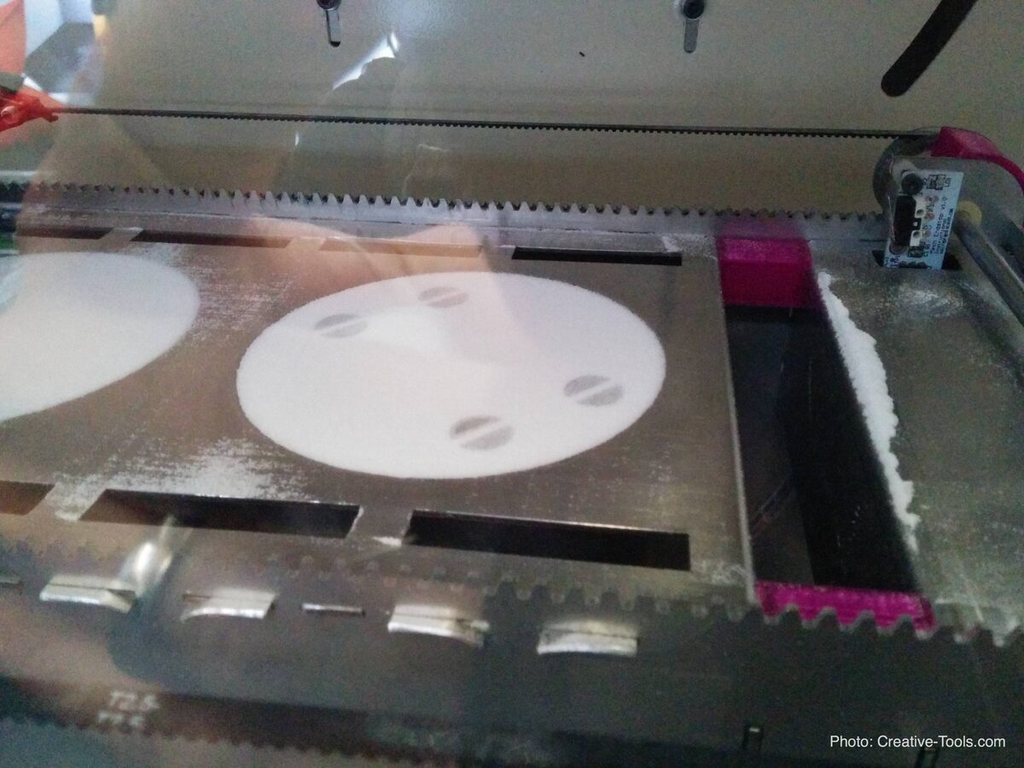

**SLS · pó**  
Um laser sinteriza seletivamente o leito de pó.

Fotos: 3D-PRINTER.jpg, [Elegoo mars.jpg](https://commons.wikimedia.org/wiki/File:Elegoo_mars.jpg) e Sharebot SnowWhite SLS, Wikimedia Commons. Licenças indicadas nas páginas-fonte.

## Aditivo, subtrativo e formativo

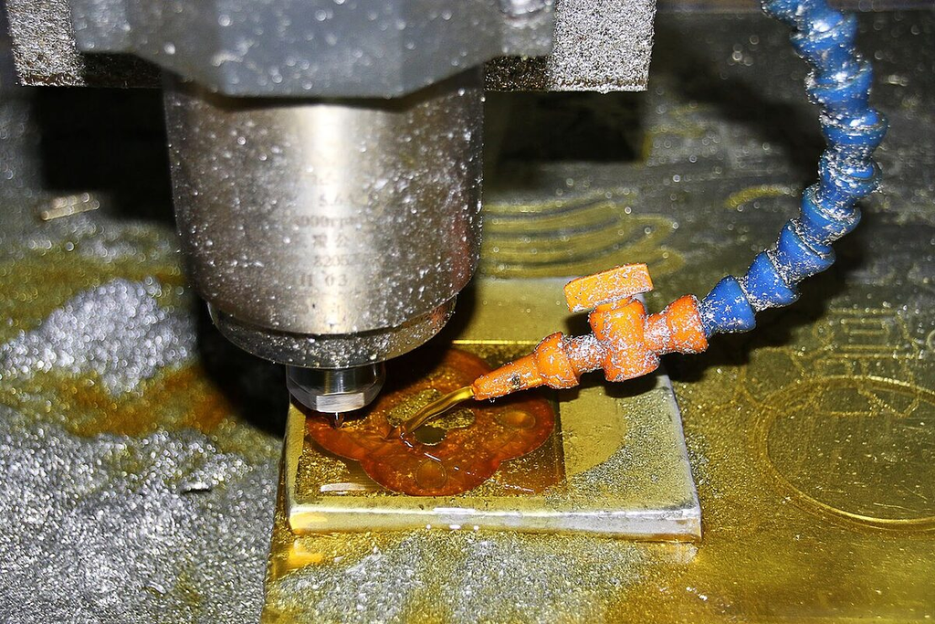

**Usinagem CNC**  
Uma ferramenta remove material de um bloco.

[figure not shown]

**Injeção de plástico**  
Material fundido preenche um molde.

**Impressão FDM**  
Material é adicionado somente onde necessário.

Fotos: [CNC milling machine.jpg](https://commons.wikimedia.org/wiki/File:CNC_milling_machine.jpg), [Injection moulding machine.jpg](https://commons.wikimedia.org/wiki/File:Injection_moulding_machine.jpg) e 3D-PRINTER.jpg, Wikimedia Commons.

## Impressoras de bancada: duas propostas

[figure not shown]

**Creality Ender 3**  
Arquitetura aberta, montagem acessível e grande comunidade de modificações.

[figure not shown]

**Bambu Lab X1 Carbon + AMS**  
Máquina fechada, automação e troca de filamento para trabalhos multicoloridos.

Fotos: [Ender 3x 3D printer kit](https://commons.wikimedia.org/wiki/Category:Creality_Ender_3), Wikimedia Commons; [Bambu Lab X1 Carbon with AMS module](https://commons.wikimedia.org/wiki/File:Bambu_Lab_X1_Carbon_with_AMS_module.jpg), CC BY-SA 4.0, Benlisquare.

## Filamento: a matéria-prima do FDM

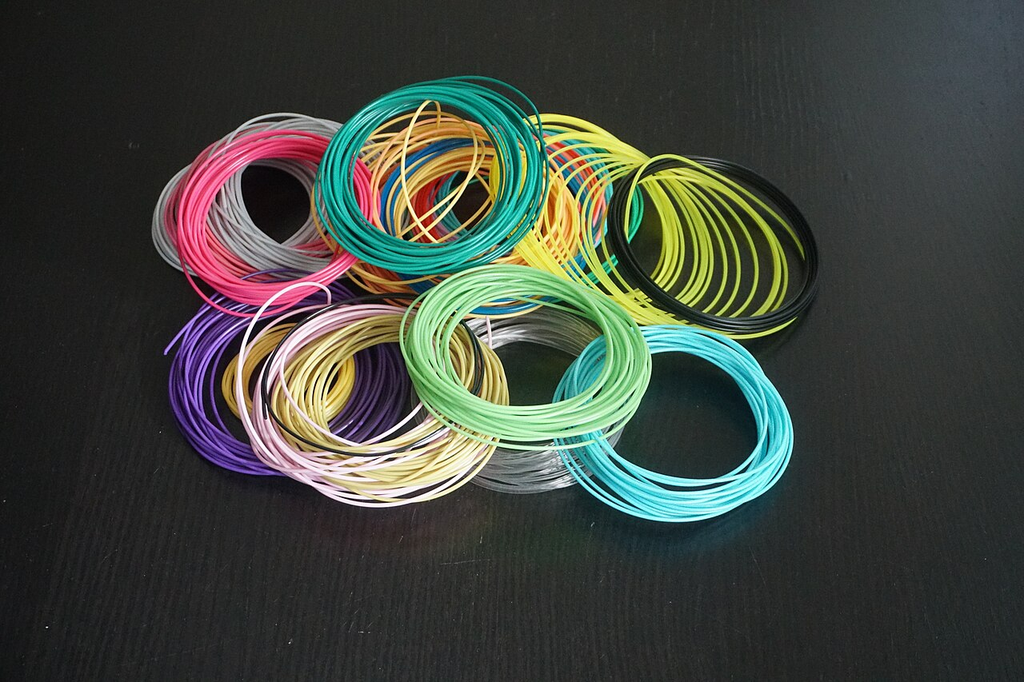

**Cores e diâmetros**  
O diâmetro nominal precisa ser compatível com o extrusor e o perfil da máquina.

**Do rolo ao bico**  
Umidade, temperatura, fluxo e armazenamento afetam diretamente o resultado.

Foto dos filamentos: [3D-Druck-Filament in verschiedenen Farben](https://commons.wikimedia.org/wiki/File:3D-Druck-Filament_in_verschiedenen_Farben.jpg), Wikimedia Commons. Foto da impressora: 3D-PRINTER.jpg, Wikimedia Commons.

## FDM colorida: como a cor chega à peça?

Uma impressora FDM colorida continua depositando **uma linha de filamento por vez**. A diferença está em como o sistema seleciona, corta, purga ou combina os filamentos.

### O fatiador precisa saber

- quais cores estão disponíveis;
- qual material está em cada canal;
- quando inserir uma troca;
- quanto material será usado na purga.

## Estratégias para imprimir em várias cores

| Estratégia | Como funciona | Vantagem | Custo ou limite |
| --- | --- | --- | --- |
| troca manual | pausa e substituição do filamento | barato e simples | exige intervenção; melhor para faixas por altura |
| dois bicos | cada extrusor recebe um filamento | troca rápida em alguns modelos | calibração, alinhamento e tamanho do conjunto |
| trocador de filamento | seleciona vários rolos para um bico | muitas cores com um hotend | tempo e material de purga |
| mistura de cores | extrusores combinam filamentos | gradientes e misturas | controle mais complexo e transições menos previsíveis |

Trocar de cor não é “gratuito”: o sistema precisa evitar que a cor anterior contamine a próxima.

## FDM colorida: purga, torre e desperdício

[figure not shown]

**Alimentação multicolorida**  
O sistema seleciona o rolo e conduz o filamento até o hotend.

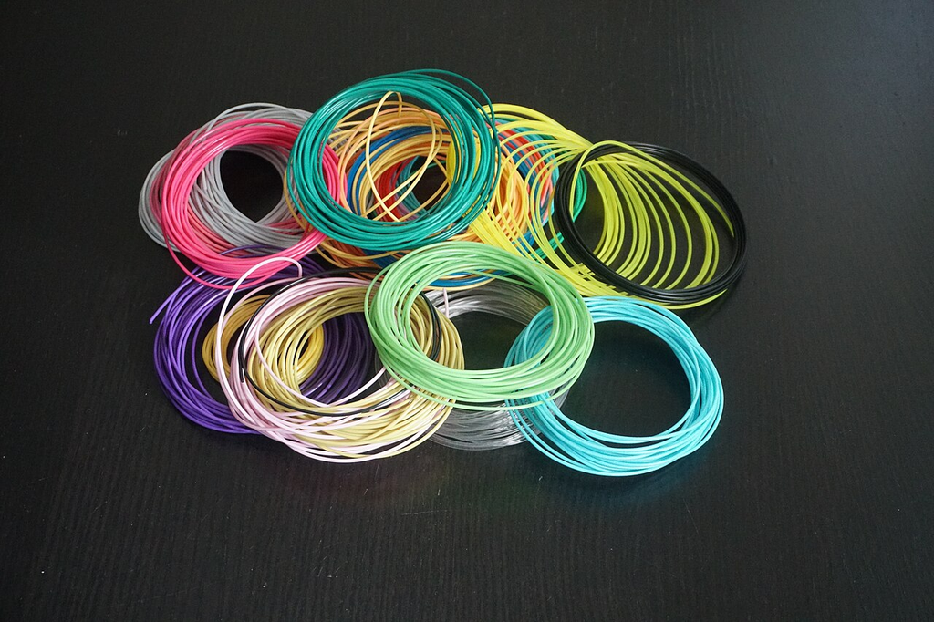

**O que o preview revela**  
Procure trocas, torre de purga, material descartado e tempo adicional.

1. o filamento antigo é retraído;
2. o novo filamento é carregado;
3. o bico purga a cor residual;
4. a impressão retoma a trajetória da peça.

Foto da Bambu Lab: [Bambu Lab X1 Carbon with AMS module](https://commons.wikimedia.org/wiki/File:Bambu_Lab_X1_Carbon_with_AMS_module.jpg), CC BY-SA 4.0, Benlisquare. Foto dos filamentos: [3D-Druck-Filament in verschiedenen Farben](https://commons.wikimedia.org/wiki/File:3D-Druck-Filament_in_verschiedenen_Farben.jpg), Wikimedia Commons.

## Vídeos recomendados para continuar

### Processos de impressão

- [Como funciona uma impressora FDM](https://www.youtube.com/watch?v=WA9iZ_EzcH4) — animação de mecânica e componentes.
- [FDM × SLA × SLS](https://www.youtube.com/watch?v=4wHonWbx3fo) — comparação de fluxo, materiais e pós-processamento.
- [Introdução à estereolitografia](https://www.youtube.com/watch?v=Ei2HGPhHPCY) — Formlabs, com foco em resina.

### Máquinas e software

- [Playlist oficial do PrusaSlicer](https://www.prusa3d.com/en/page/prusaslicer_426/) — recursos do fatiador.
- [Vídeos da Bambu Lab](https://www.youtube.com/@BambuLab/videos) — automação e impressão multicolorida.
- [Vídeos da Haas Automation](https://www.youtube.com/@HaasAutomation/videos) — CNC, ferramentas e automação industrial.

## Resina: detalhe, luz e pós-processamento

[figure not shown]

**Impressora SLA/MSLA**  
Uma fonte de luz cura seletivamente a resina líquida.

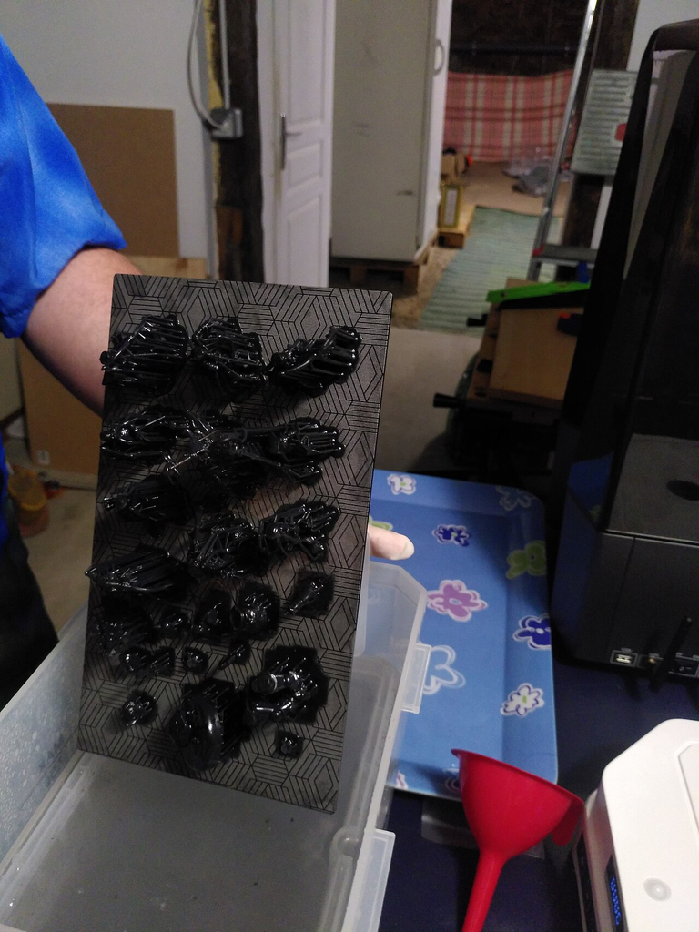

**Peça antes da limpeza**  
Lavagem, remoção de suportes e cura UV fazem parte do processo.

Fotos: [Elegoo mars.jpg](https://commons.wikimedia.org/wiki/File:Elegoo_mars.jpg) e [Résultat d’une impression 3D avant nettoyage](https://commons.wikimedia.org/wiki/File:R%C3%A9sultat_d%E2%80%99une_impression_3D_avant_nettoyage.jpg), Wikimedia Commons.

## Impressão em pó: SLS e o leito de fabricação

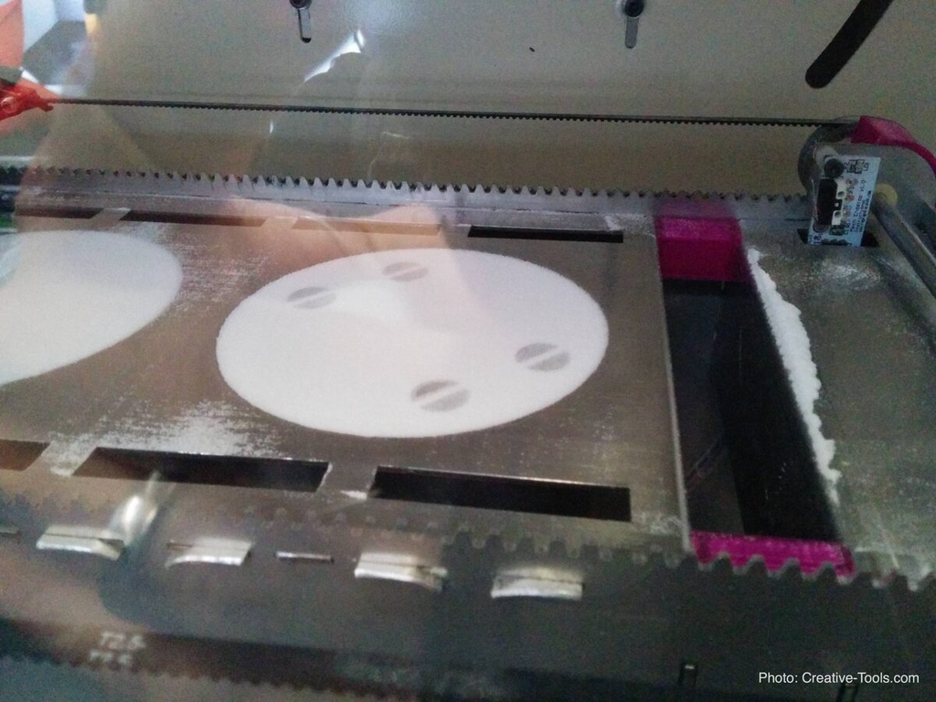

**Leito de pó**  
O material não sinterizado ao redor da peça pode oferecer suporte geométrico.

[figure not shown]

**Depois da fabricação**  
Peças técnicas podem seguir para limpeza, inspeção, usinagem ou acabamento.

Foto SLS: Sharebot SnowWhite SLS, Wikimedia Commons. A foto CNC é usada no slide seguinte como comparação industrial.

## Escala industrial: CNC robotizada e injeção

[figure not shown]

**Usinagem CNC automatizada**  
Remove material com ferramentas rígidas; robôs podem carregar, descarregar e organizar peças.

[figure not shown]

**Injeção de plástico**  
Um molde define a forma e a automação favorece alta repetibilidade e volume.

Fotos: [EGU-Metall CNC-Fräsen mit Roboterautomatisierung](https://commons.wikimedia.org/wiki/File:EGU-Metall_CNC-Fr%C3%A4sen_mit_Roboterautomatisierung.jpg) e [Injection Molding Machine with a robot arm](https://commons.wikimedia.org/wiki/File:Injection_Molding_Machine_with_a_robot_arm.jpg), Wikimedia Commons.

## Componentes reais: hotend e extrusão

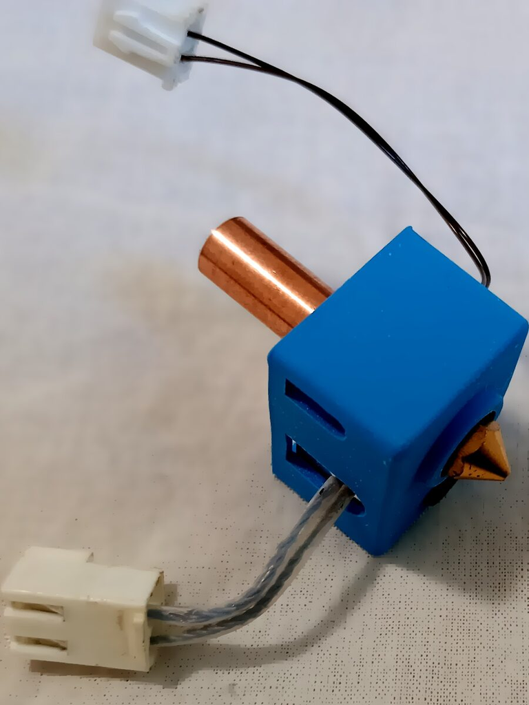

### Observe na fotografia

O hotend controla a fusão; o extrusor controla a alimentação. São funções relacionadas, mas não são a mesma peça.

Foto: Hotend.jpg, Wikimedia Commons.

## Componentes reais: placa, fonte e mecânica

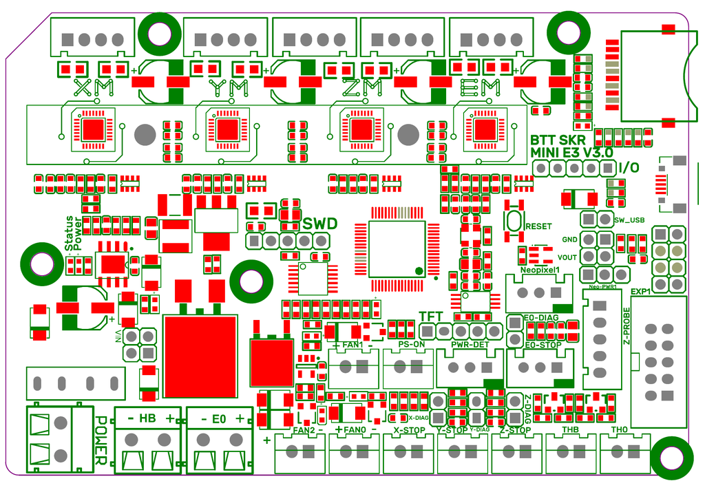

**BTT SKR Mini E3 V3.0**  
Placa de controle: interpreta o G-code e aciona motores, aquecedores e sensores.

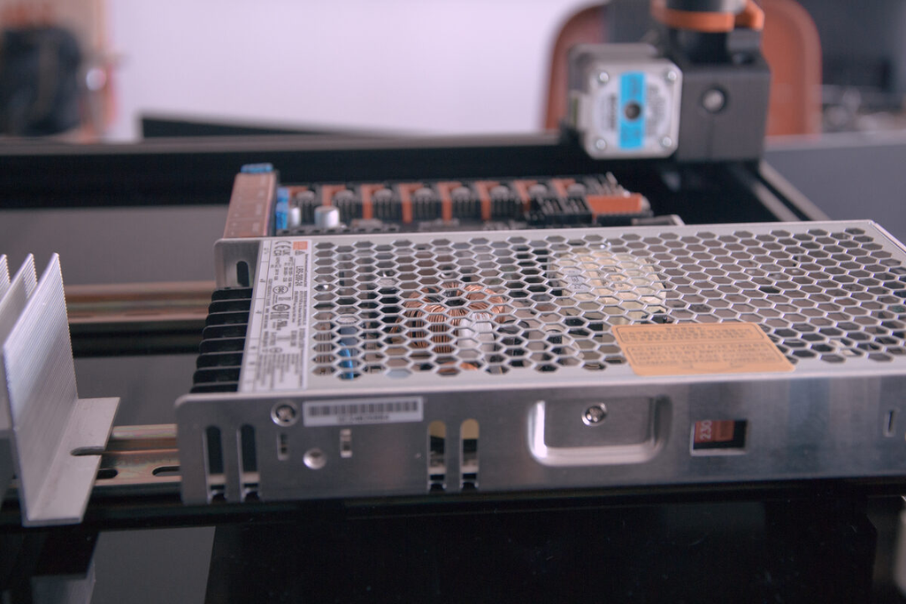

**Eletrônica e fonte**  
A fonte fornece energia; conexões e ventilação importam.

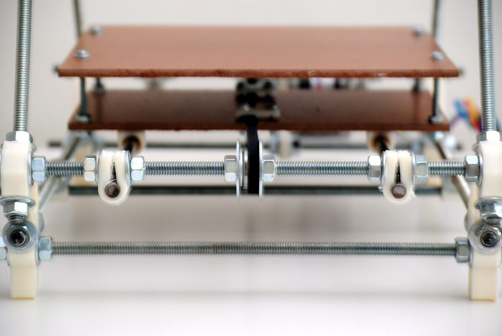

**Correia e rolamento**  
Transmitem movimento e guiam o eixo com baixa folga.

Foto da placa: documentação da [BTT SKR Mini E3 V3.0](https://github.com/bigtreetech); demais fotos: [Electronics of 3D Printer.jpg](https://commons.wikimedia.org/wiki/File:Electronics_of_3D_Printer.jpg) e [Y-axis y-belt and bearing.jpg](https://commons.wikimedia.org/wiki/File:Y-axis_y-belt_and_bearing.jpg), Wikimedia Commons.

## Mapa da oficina

| Bloco | Tempo | Saída esperada |
| --- | --- | --- |
| Contexto e fundamentos | 0–25 min | Entender o que muda na fabricação aditiva |
| Tecnologias, FDM e Ender 3 Pro | 25–80 min | Reconhecer mecanismos e componentes |
| PrusaSlicer + Benchy | 80–115 min | Baixar, importar e fatiar um Benchy |
| Intervalo | 115–125 min | — |
| Preview, diagnóstico e decisões | 125–165 min | Comparar configurações e justificar escolhas |
| Fechamento | 165–180 min | Aplicações, impressão e sorteio |

## O que é fabricação aditiva?

### Material é colocado onde precisa

Um objeto é construído **camada a camada** a partir de um modelo digital. A geometria nasce por adição localizada de material.

Não é “imprimir uma imagem”: é executar uma sequência de trajetórias em três dimensões.

## Comparação entre processos de fabricação

| Processo | O que acontece | Vantagem típica | Limitação típica |
| --- | --- | --- | --- |
| **Aditivo** | adiciona material | geometrias internas e personalização | anisotropia, tempo por peça |
| Subtrativo | remove de um bloco | precisão e materiais variados | desperdício, acesso da ferramenta |
| Formativo | molda/transforma | custo baixo em grande volume | molde e projeto inicial |

## Três famílias, três mecanismos

[figure not shown]

Comparação entre FDM/FFF, SLA/MSLA e SLS

## FDM: o ciclo de uma camada

[figure not shown]

Bico depositando filamento em camadas

1. O motor do extrusor empurra o filamento.
2. O hotend aquece até a faixa adequada do material.
3. O bico deposita uma linha com largura e velocidade controladas.
4. A mesa ou o pórtico se desloca para a próxima camada.

## A Ender 3 Pro por dentro

[figure not shown]

Diagrama dos componentes principais da Ender 3 Pro

## O que cada parte controla

| Subsistema | Função | Sintoma quando há problema |
| --- | --- | --- |
| Extrusor / hotend | fundir e dosar material | subextrusão, entupimento |
| Eixos X/Y/Z | posicionar o bico/mesa | deslocamento, camada irregular |
| Mesa | sustentar e aquecer | warping, peça solta |
| Ventilação | solidificar e resfriar | pontes ruins, deformação |
| Eletrônica | interpretar G-code e acionar motores | falhas, ruído, parada |

## Materiais: escolha é compromisso

### PLA

Fácil, rígido, baixa contração. Bom ponto de partida; não é ideal para calor elevado.

### PETG

Mais tenaz e resistente a temperatura; pode formar fios e aderir demais à mesa.

### ABS / ASA

Resistentes e mais exigentes: contração, ambiente controlado e ventilação adequada.

### TPU

Flexível; exige caminho do filamento bem guiado e velocidades menores.

## Cinco parâmetros que mudam o resultado

altura de camada largura de linha paredes preenchimento suportes

**Altura menor** → mais detalhe vertical, mais camadas e tempo.

**Mais paredes** → resistência nas superfícies e maior consumo.

**Mais preenchimento** não resolve tudo: orientação e paredes importam.

**Suporte** viabiliza balanços, mas deixa marcas e exige remoção.

## Geometria e arquivos: o que pode dar errado

### No modelo

- malha aberta ou superfícies invertidas;
- paredes mais finas que o bico consegue formar;
- detalhes pequenos demais para a escala;
- folgas insuficientes entre peças móveis.

### No arquivo

- STL guarda a superfície, não o projeto paramétrico;
- unidades podem causar escala incorreta;
- 3MF pode transportar perfil e configurações;
- sempre confira dimensões e orientação no fatiador.

Um arquivo baixado não é automaticamente imprimível: a geometria precisa ser conferida no contexto da máquina, do bico e do material.

## Do modelo ao movimento da máquina

[figure not shown]

Fluxo de produção: modelagem, arquivo, fatiamento, G-code e impressão

## Antes de imprimir: pense como engenheiro

### Geometria

- paredes com espessura real;
- folgas para peças móveis;
- orientação e balanços;
- raio ou chanfro onde necessário.

### Uso

- carga e temperatura;
- acabamento desejado;
- tolerância dimensional;
- segurança e pós-processamento.

## Prática 1 · preparar as ferramentas

35 min

**Entrega:** o PrusaSlicer aberto, o Benchy importado e um primeiro fatiamento pronto para análise.

1. Baixe o ZIP do **PrusaSlicer para Windows** na página oficial.
2. Extraia o ZIP em uma pasta local — por exemplo, `C:\Ferramentas\PrusaSlicer`.
3. Execute `prusa-slicer.exe`. O pacote portátil não exige instalação administrativa.
4. Baixe o arquivo `3DBenchy.stl` do Thingiverse e salve-o na mesma pasta de trabalho.

## Downloads · use fontes confiáveis

### PrusaSlicer

Página oficial: help.prusa3d.com/downloads/prusaslicer

Escolha o ZIP **Windows Win64**. Extraia tudo antes de executar.

### 3DBenchy

Modelo original: thingiverse.com/thing:763622

Em **Thing Files**, baixe o `3DBenchy.stl` — não uma imagem nem um arquivo de projeto.

## Prática 1 · importe o Benchy

### No PrusaSlicer

1. Arraste `3DBenchy.stl` para a janela.
2. Aceite a conversão para o formato interno, se aparecer.
3. Confirme que o barco está apoiado na mesa.

### Antes de fatiar

- confira escala e unidades;
- selecione uma impressora disponível;
- escolha PLA e o bico instalado;
- mantenha as configurações padrão.

## Antes de fatiar: faça uma previsão

### Observe o Benchy

- a base tem área suficiente?
- quais paredes são finas?
- onde há balanços ou pontes?
- quais detalhes exigem boa resolução?

### Registre sua hipótese

- haverá suportes?
- onde aparecerão fios?
- qual parte será mais lenta?
- que região pode perder detalhes?

Primeiro faça uma previsão. Depois use o preview para confirmar ou refutar cada hipótese.

## Intervalo · 10 min

## Pausa rápida

Observe a impressora com segurança: **não toque no bico ou na mesa aquecida**.

Volte com o PrusaSlicer aberto e o Benchy importado.

## Prática 2 · fatiar com o PrusaSlicer

### 1 · manter o perfil padrão

1. Confirme a impressora e o bico selecionados.
2. Use o modo **Print settings** com o perfil padrão.
3. Não altere altura de camada, preenchimento ou suportes nesta primeira rodada.
4. Clique em **Slice now**.

O objetivo é comparar o resultado de uma configuração reproduzível. Depois, podemos investigar qual parâmetro explica cada detalhe do Benchy.

## O que o perfil padrão decide?

| Ajuste | Ponto de partida didático | Efeito principal |
| --- | --- | --- |
| Altura de camada | 0,20 mm | detalhe × tempo |
| Paredes / perímetros | perfil padrão | resistência superficial |
| Preenchimento | perfil padrão | massa e rigidez |
| Suportes | perfil padrão | balanços × marcas |
| Adesão | perfil padrão | primeira camada |

## Compare configurações: uma variável por vez

| Experimento | Alteração | O que observar |
| --- | --- | --- |
| A | altura 0,15 mm × 0,30 mm | detalhe vertical e tempo |
| B | 10% × 30% de preenchimento | massa, tempo e rigidez interna |
| C | 2 × 4 perímetros | paredes e resistência superficial |
| D | suportes desligados × ligados | balanços, marcas e material extra |

Não mude quatro parâmetros ao mesmo tempo: assim fica difícil saber qual alteração causou o efeito observado.

## PrusaSlicer · leia o preview

### Investigue o Benchy

- onde começa a primeira camada?
- quais paredes são perímetros?
- onde aparecem pontes e balanços?
- como o preenchimento se distribui?
- quais partes revelam a qualidade do fluxo?

## PrusaSlicer · tempo, material e G-code

1. Clique em **Slice now**.
2. Compare tempo e massa estimados.
3. Examine a prévia: paredes, preenchimento, suportes e deslocamentos.
4. Salve o projeto do PrusaSlicer para repetir o experimento.
5. Exporte o G-code somente após conferir a máquina e o cartão/USB.

O tempo exibido é uma estimativa. A impressão real pode variar com aceleração, pausas, temperatura e firmware.

## Orientação da peça: três decisões diferentes

### Melhor acabamento

Mais faces importantes voltadas para cima e menos marcas de suporte.

### Mais resistência

As camadas devem acompanhar a direção das cargas; a resistência entre camadas é diferente da resistência dentro da camada.

### Mais estabilidade

Uma base maior reduz o risco de descolamento, mas pode aumentar tempo e material.

## Diagnóstico de falhas: observe antes de mexer

| Sintoma | Causas prováveis | Primeira verificação |
| --- | --- | --- |
| fios entre partes | retração, temperatura, umidade | preview, temperatura e retração |
| cantos levantados | contração, mesa fria ou suja | adesão e temperatura da mesa |
| camada deslocada | correia, polia, colisão ou aceleração | aperto mecânico e trajetória |
| linhas faltando | entupimento, fluxo ou tensão no extrusor | caminho do filamento e hotend |
| primeira camada irregular | nivelamento ou malha da mesa | altura do bico e superfície |

Diagnóstico é uma hipótese testável: altere uma causa por vez e compare com uma impressão ou preview de referência.

## Segurança e confiabilidade

### Durante a impressão

- mantenha cabos e mãos longe dos eixos;
- não toque em bico/mesa aquecidos;
- observe ruídos e deslocamentos;
- interrompa se houver risco.

### Controle de qualidade

- primeira camada aderida;
- fluxo sem falhas;
- dimensões compatíveis;
- acabamento adequado ao uso.

## Desafio rápido: escolha a primeira verificação

Relacione cada sintoma com a primeira hipótese a investigar:

| Situação observada | Primeira verificação |
| --- | --- |
| A peça se soltou no início | limpeza, nivelamento e adesão da mesa |
| O Benchy tem muitos fios | temperatura e retração |
| Uma camada aparece deslocada | correia, polia e possível colisão |
| As paredes têm falhas | fluxo, bico e caminho do filamento |

Antes de alterar o perfil inteiro, observe o sintoma, formule uma hipótese e mude uma variável por vez.

## O que mudou recentemente?

| Avanço | O que melhora | O que continua exigindo entendimento |
| --- | --- | --- |
| maior velocidade | tempo de produção | vibração, fluxo, resfriamento |
| input shaping | ringing/ghosting | calibração e rigidez |
| calibração automática | malha/primeira camada | superfície limpa e mecânica |
| multicolor | aparência e materiais | troca, purga e desperdício |
| monitoramento | repetibilidade | sensores e configuração |

## Onde a impressão 3D faz sentido?

**Excelente para:** - prototipagem e iteração; - gabaritos e suportes; - peças personalizadas; - educação e acessibilidade; - produção em baixo volume.

**Exige cuidado em:** - peças críticas de segurança; - alta temperatura e carga contínua; - tolerâncias muito apertadas; - grandes séries; - descarte, fumos e pós-processamento.

## Referência rápida para levar

**Fluxo:** CAD → STL/3MF → PrusaSlicer → G-code → primeira camada → peça.  
**Comece simples:** PLA, 0,20 mm, 3 paredes, 15–20% de preenchimento, orientação com boa base.  
**Verifique sempre:** material, perfil, bico, mesa, temperatura, suportes, preview e segurança.  
**Repositórios:** Printables, Thingiverse, MakerWorld e modelos próprios — confira licença, escala e integridade antes de imprimir.